# Thinks Stats: Chapter 3 - Probability Mass Function

## Pmfs

A **distribution** is a mapping between values in the sample and their frequency.  
A **PMF** is a mapping between values in the sample and their probability (or relative frequency).  
**Normalization** is the process of dividing all frequencies by the sample size `n`.

```python
import thinkstats2
import thinkplot
import math
import numpy as np
import seaborn # it makes the plots look better because of the styling
```

```python
# Let's represent a distribution through its histogram
hist = thinkstats2.Hist([1, 2, 2, 3, 5])
hist
```

```
Hist({1: 1, 2: 2, 3: 1, 5: 1})
```

```python
n = hist.Total()
print "n =", n
d = {}
for x, freq in hist.Items():
    d[x] = freq / float(n) # Python 2.7 performs integer division, thus, we need to convert to float
print d
```

```
n = 5
{1: 0.2, 2: 0.4, 3: 0.2, 5: 0.2}
```

The total mass in a PMF should always be one:

```python
sum(d.values())
```

```
1.0
```

### `Pmf` class in thinkstats2

The same way that there was a class `Hist`, there is a class `Pmf` to store the values of a PMF.  
The result below will be the same as the one we calculated earlier.

```python
pmf = thinkstats2.Pmf([1, 2, 2, 3, 5])
pmf
```

```
Pmf({1: 0.2, 2: 0.4, 3: 0.2, 5: 0.2})
```

**Methods of Pmf**

```python
print dir(pmf)
```

[output not shown]

```python
# picks a random value from the pmf
pmf.Random()
```

```
2
```

```python
# calculates the mean of the sample
pmf.Mean()
```

```
2.6
```

```python
# return the probability value of one of the items
pmf.Prob(3)
```

```
0.2
```

```python
# the total of prob. values is 1
pmf.Total()
```

```
1.0
```

We can modify the pmf by adding or multiplying, with `.Incr()` and `.Mult()`.

```python
pmf.Incr(3, 0.1)
pmf
```

```
Pmf({1: 0.2, 2: 0.4, 3: 0.30000000000000004, 5: 0.2})
```

If we do this, the pmf is not normalized anymore (that is, the sum of probs. is not 1).

```python
pmf.Total()
```

```
1.1
```

```python
pmf.Normalize()
```

```
1.1
```

Check that normalization happened:

```python
pmf.Total()
```

```
1.0
```

Let's check how the probabilities look like:

```python
pmf
```

```
Pmf({1: 0.18181818181818182, 2: 0.36363636363636365, 3: 0.27272727272727276, 5: 0.18181818181818182})
```

## Plotting PMFs

1. Use a bar graph if the number of the values in the Pmf is small
2. Use a step function when there is a large number of values.

Let's try to plot Pmf-s for the two groups: first babies and other that we calculated in Chapter 2.

```python
from chap02 import *

first_pmf = thinkstats2.Pmf(firsts.prglngth, label='first')
other_pmf = thinkstats2.Pmf(others.prglngth, label='other')
```

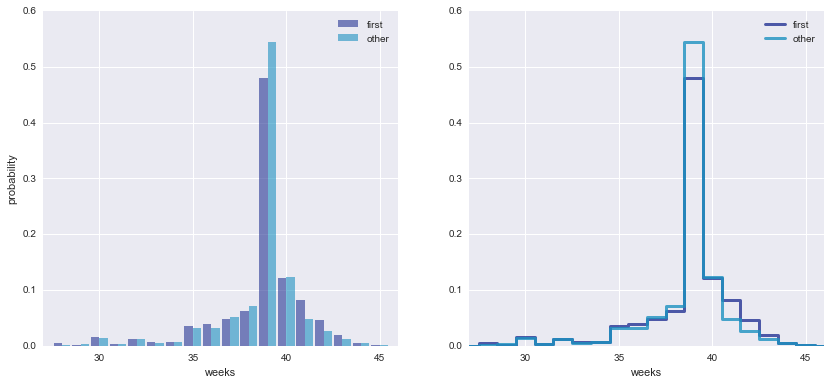

```python
%matplotlib inline

width = 0.45
thinkplot.PrePlot(2, cols=2)
thinkplot.Hist(first_pmf, align='right', width=width)
thinkplot.Hist(other_pmf, align='left', width=width)
thinkplot.Config(xlabel='weeks',
                 ylabel='probability',
                 axis=[27, 46, 0, 0.6])

# creates the step function
thinkplot.PrePlot(2)
thinkplot.SubPlot(2)
thinkplot.Pmfs([first_pmf, other_pmf])
thinkplot.Show(xlabel='weeks',
                axis=[27, 46, 0, 0.6])
```

**Question:** Why is plotting the PMF useful?  
What can we say about the birth of first babies from this plot?

**Answer:** It's useful because it enables you to visualize the data, rather than just viewing the raw numbers. It also helps create a direct comparison between the first babies and the other ones. It seems as though the first babies are born slightly later than the other ones.

### Visualizing the difference between the Pmf-s

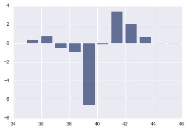

```python
weeks = range(35, 46)
diffs = []
for week in weeks:
    p1 = first_pmf.Prob(week)
    p2 = other_pmf.Prob(week)
    diff = 100 * (p1 - p2)
    diffs.append(diff)
thinkplot.Bar(weeks, diffs)
```

### The class size paradox

Assume that we have a college with the following distribution of class sizes:

```
 size        count
 5- 9          8
10-14          8
15-19         14
20-24          4
25-29          6
30-34         12
35-39          8
40-44          3
45-49          2
```

This distribution can be simplified by using the average size class for each group, 5-9 has average 7, 10-14 has average 12, etc.

```python
d = { 7: 8, 12: 8, 17: 14, 22: 4, 27: 6, 32: 12, 37: 8, 42: 3, 47: 2}
```

Let's create the Pmf of this distribution:

```python
pmf = thinkstats2.Pmf(d, label='actual')
pmf
```

```
Pmf({32: 0.18461538461538463, 37: 0.12307692307692308, 7: 0.12307692307692308, 42: 0.046153846153846156, 12: 0.12307692307692308, 47: 0.03076923076923077, 17: 0.2153846153846154, 22: 0.06153846153846154, 27: 0.09230769230769231})
```

```python
print 'mean', pmf.Mean()
```

```
mean 23.6923076923
```

Thus, the class size average is about 23.7 students. Does is feel the same way for students too?

```python
def BiasPmf(pmf, label):
    """Returns the Pmf with oversampling proportional to value.

    If pmf is the distribution of true values, the result is the
    distribution that would be seen if values are oversampled in
    proportion to their values; for example, if you ask students
    how big their classes are, large classes are oversampled in
    proportion to their size.

    Args:
      pmf: Pmf object.
      label: string label for the new Pmf.

     Returns:
       Pmf object
    """
    new_pmf = pmf.Copy(label=label)
    for x, p in pmf.Items():
        new_pmf.Mult(x, x)
    new_pmf.Normalize()
    return new_pmf
```

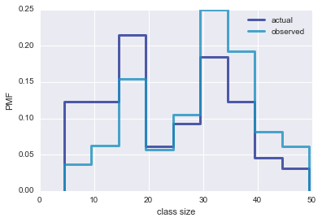

```python
biased_pmf = BiasPmf(pmf, label='observed')
thinkplot.PrePlot(2)
thinkplot.Pmfs([pmf, biased_pmf])
thinkplot.Show(xlabel='class size', ylabel='PMF')
```

```python
print 'biased mean', biased_pmf.Mean()
```

```
biased mean 29.1233766234
```

### Dataframe indexing

Create a simple dataframe:

```python
import numpy as np
import pandas
array = np.random.randn(4, 2)
df = pandas.DataFrame(array)
```

Assign names to columns:

```python
columns = ['A', 'B']
df = pandas.DataFrame(array, columns=columns)
df
```

|  | A | B |
| --- | --- | --- |
| 0 | 0.567970 | -0.652352 |
| 1 | -1.975562 | 1.948668 |
| 2 | 1.056476 | 0.672305 |
| 3 | -0.321929 | -0.900080 |

Assign names to rows:

```python
index = ['a', 'b', 'c', 'd']
df = pandas.DataFrame(array, columns=columns, index=index)
df
```

|  | A | B |
| --- | --- | --- |
| a | 0.567970 | -0.652352 |
| b | -1.975562 | 1.948668 |
| c | 1.056476 | 0.672305 |
| d | -0.321929 | -0.900080 |

Access a column:

```python
df['B']
```

```
a   -0.652352
b    1.948668
c    0.672305
d   -0.900080
Name: B, dtype: float64
```

Different ways to access a row:

```python
df.loc['b']
```

```
A   -1.975562
B    1.948668
Name: b, dtype: float64
```

```python
df.iloc[2]
```

```
A    1.056476
B    0.672305
Name: c, dtype: float64
```

```python
df['a':'c']
```

|  | A | B |
| --- | --- | --- |
| a | 0.567970 | -0.652352 |
| b | -1.975562 | 1.948668 |
| c | 1.056476 | 0.672305 |

```python
df[1:3]
```

|  | A | B |
| --- | --- | --- |
| b | -1.975562 | 1.948668 |
| c | 1.056476 | 0.672305 |

## Exercises

Let's read the data from the Female Respondent dataset (that we used in Chapter 02).

```python
import chap02
resp = chap02.ReadFemResp()
```

**E1:** Make a PMF of `numkdhh`, the number of children under 18 in the respondent's household.

```python
resp["numkdhh"]
kidPmf = thinkstats2.Pmf(resp.numkdhh, label="Kids")
kidPmf
```

```
Pmf({0: 0.46617820227659301, 1: 0.21405207379301322, 2: 0.19625801386889966, 3: 0.087138558157791451, 4: 0.025644380478869556, 5: 0.010728771424833181})
```

**E2:** Display this PMF

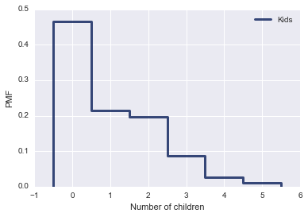

```python
thinkplot.Pmf(kidPmf)
thinkplot.Show(xlabel='Number of children', ylabel='PMF')
```

**E3:** Make a the biased Pmf of children in the household, as observed if you surveyed the children instead of the respondents. (use BiasPmf from above)

```python
biasedPmfKids = BiasPmf(kidPmf, label="Biased number of kids")
biasedPmfKids
```

```
Pmf({0: 0.0, 1: 0.20899335717935616, 2: 0.38323965252938175, 3: 0.25523760858456823, 4: 0.10015329586101177, 5: 0.052376085845682166})
```

**E4:** Display the actual Pmf and the biased Pmf on the same axes.

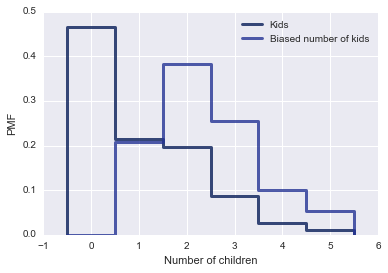

```python
thinkplot.Pmfs([kidPmf, biasedPmfKids])
thinkplot.Show(xlabel='Number of children', ylabel='PMF')
```

**E5:** Compute the means of the two Pmfs.

```python
print 'Mean of kids:', kidPmf.Mean()
print 'Biased mean of kids:', biasedPmfKids.Mean()
```

```
Mean of kids: 1.02420515504
Biased mean of kids: 2.40367910066
```